# How Good Is the Line?

Lesson 29 — Residuals, R-Squared, and Outliers

Lt Col Cho

# Where We Left Off

We have a line. How good is it?

Residuals · Extrapolation · R-squared · Outliers · Is it a good model?

## Last lesson’s line

```r
library(tidyverse)

cadets <- read_csv(
  "https://philipycho.github.io/public_usafa/DS220_Fall2026/simulated_cadets.csv"
)
```

```r
model <- lm(gpa ~ avg_study_hours,
            data = cadets)
coef(model)
```

```
    (Intercept) avg_study_hours
     1.33926184      0.07772248
```

$$\widehat{\text{GPA}} = 1.339 + 0.0777 \times \text{hours}$$

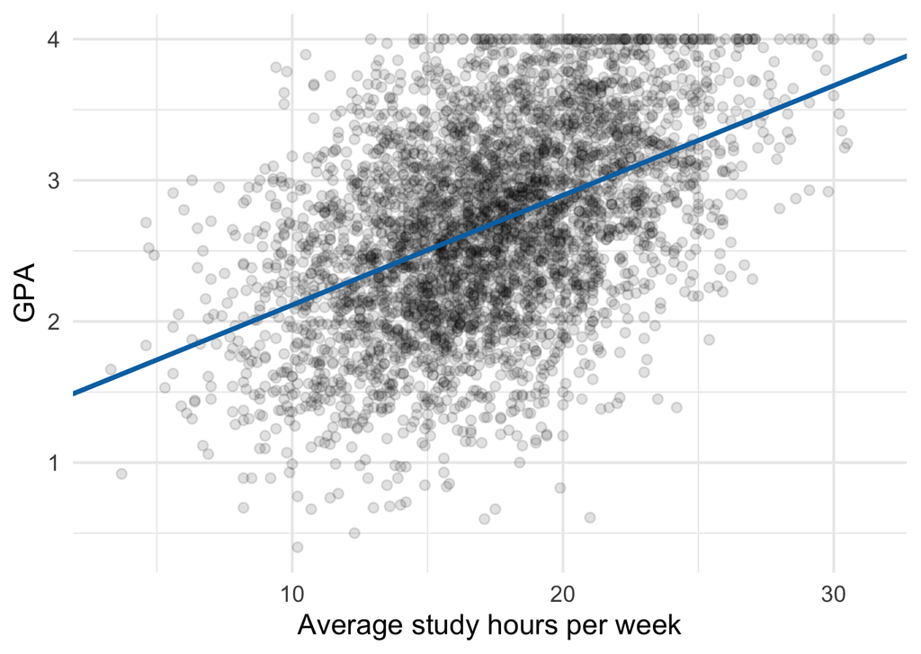

Lots of cadets sit **far** from the line. How far off are we, and does it matter?

# Residuals

How far off is each prediction?

## Residual = observed − predicted

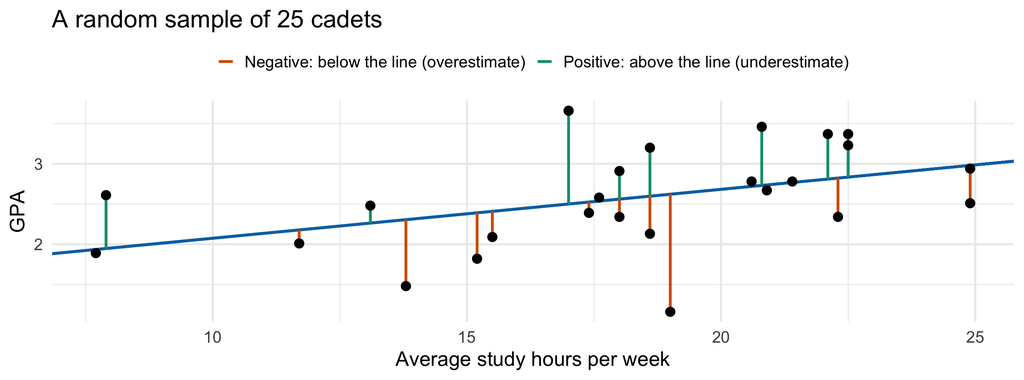

$$e_i = y_i - \hat{y}_i
\qquad\qquad
\text{Data} = \text{Fit} + \text{Residual}$$

## Computing residuals

$$\widehat{\text{GPA}} = 1.466 + 0.0609 \times \text{hours}$$

```r
cadet_sample |>
  mutate(gpa_hat  = 1.466 + 0.0609 * avg_study_hours,
         residual = gpa - gpa_hat) |>
  select(cadet_id, avg_study_hours, gpa, gpa_hat, residual) |>
  head(5)
```

```
# A tibble: 5 × 5
  cadet_id avg_study_hours   gpa gpa_hat residual
  <chr>              <dbl> <dbl>   <dbl>    <dbl>
1 C03550              19    1.16    2.62   -1.46
2 C01563              18.6  3.2     2.60    0.601
3 C00692              22.5  3.37    2.84    0.534
4 C00104              11.7  2.01    2.18   -0.169
5 C03202              18    2.34    2.56   -0.222
```

Positive residual → the line **underestimated** that cadet · negative → **overestimated**

## Residual plot: tip the scatterplot over

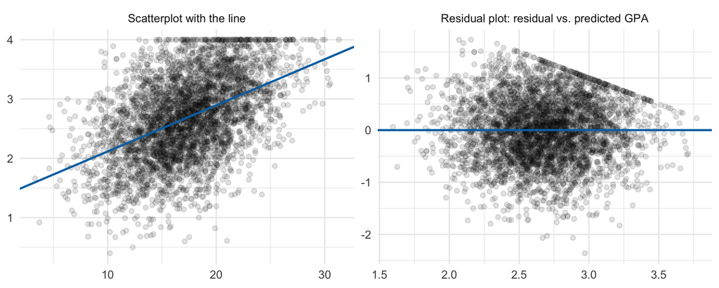

```r
cadets |>
  mutate(fitted = fitted(model), residual = resid(model)) |>
  ggplot(aes(x = fitted, y = residual)) +
  geom_point(alpha = 0.2) +
  geom_hline(yintercept = 0)
```

A shapeless cloud around 0 → a straight line is a reasonable shape

## What residual plots can warn you about

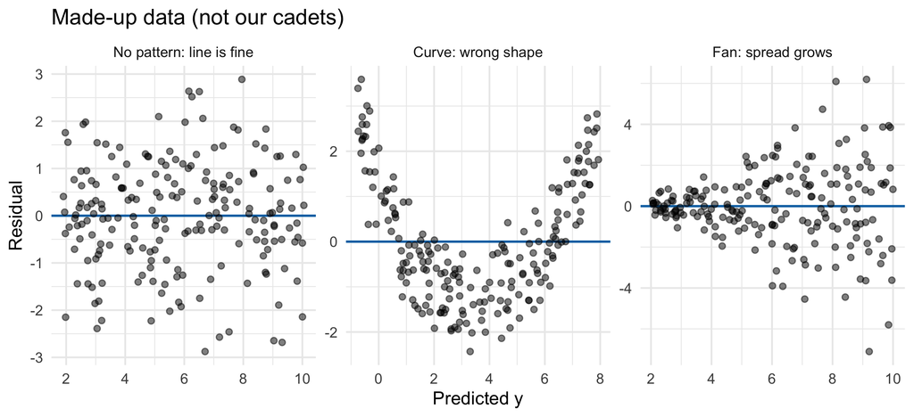

**Random scatter** is what we want. A **curve** or a **fan** means the line is missing something.

# Extrapolation

Where can we trust a prediction?

## Stay inside the data

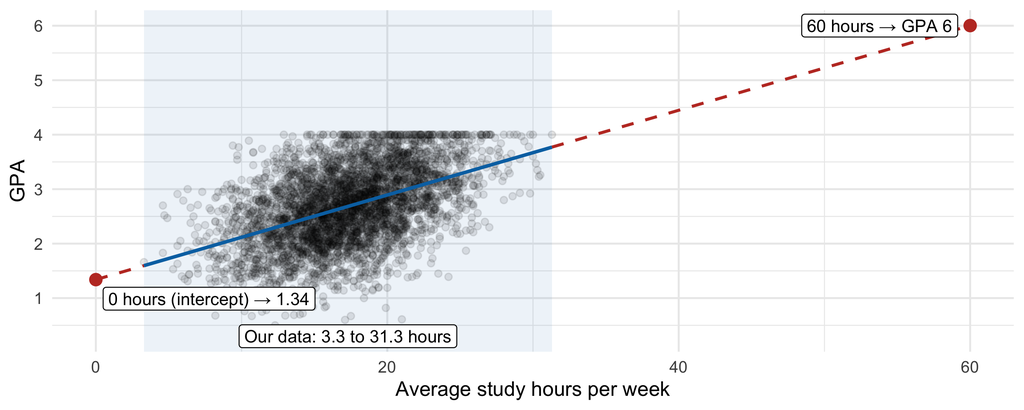

**Extrapolation:** using the line **outside the range** of the data. That includes the intercept.

# R-Squared

How much of the variation does the line explain?

## Before and after the line

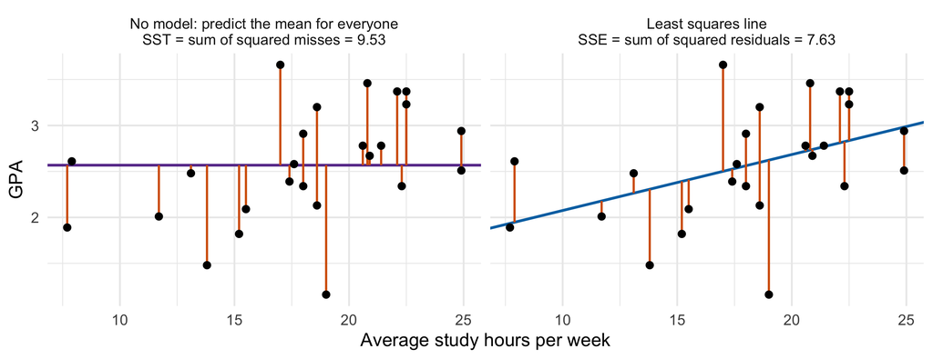

$$R^2 = 1 - \frac{SSE}{SST}
= 1 - \frac{7.63}{9.53}
= 0.20$$

## $R^2$ for all the cadets

```r
summary(model)
```

```
Call:
lm(formula = gpa ~ avg_study_hours, data = cadets)

Residuals:
     Min       1Q   Median       3Q      Max
-2.36143 -0.42829 -0.00242  0.43619  1.73465

Coefficients:
                Estimate Std. Error t value Pr(>|t|)
(Intercept)     1.339262   0.041065   32.61   <2e-16 ***
avg_study_hours 0.077722   0.002308   33.67   <2e-16 ***
---
Signif. codes:  0 '***' 0.001 '**' 0.01 '*' 0.05 '.' 0.1 ' ' 1

Residual standard error: 0.6177 on 4033 degrees of freedom
Multiple R-squared:  0.2195,    Adjusted R-squared:  0.2193
F-statistic:  1134 on 1 and 4033 DF,  p-value: < 2.2e-16
```

### Coefficient of determination

$R^2$ = proportion of the variation in $y$ explained by the model

Always between **0** and **1**

Study hours explain about **22%** of the variation in cadet GPA

## $R^2 = r^2$ (with one numerical predictor)

```r
cadets |>
  summarize(r = cor(gpa, avg_study_hours),
            r_squared = r^2)
```

```
# A tibble: 1 × 2
      r r_squared
  <dbl>     <dbl>
1 0.468     0.219
```

|  | Correlation $r$ | $R^2$ |
| --- | --- | --- |
| Measures | strength and **direction** of a linear relationship | share of variation in $y$ the model explains |
| Range | −1 to 1 | 0 to 1 |
| Works for | two **numerical** variables | any model, including categorical or several predictors |

## What different $R^2$ values look like

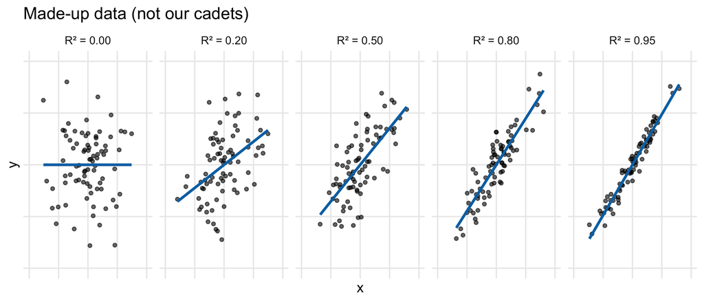

Our cadets: $R^2$ = 0.22, about like the second panel. A real trend, plenty of scatter.

## Comparing predictors with $R^2$

```r
summary(lm(gpa ~ avg_study_hours, data = cadets))$r.squared
summary(lm(gpa ~ academic_major,  data = cadets))$r.squared
summary(lm(gpa ~ pea,             data = cadets))$r.squared
```

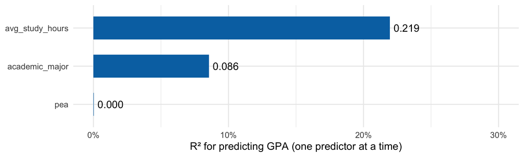

Higher $R^2$ = explains more of the variation · $R^2$ works even for a **categorical** predictor like major

## What $R^2$ does **not** tell you

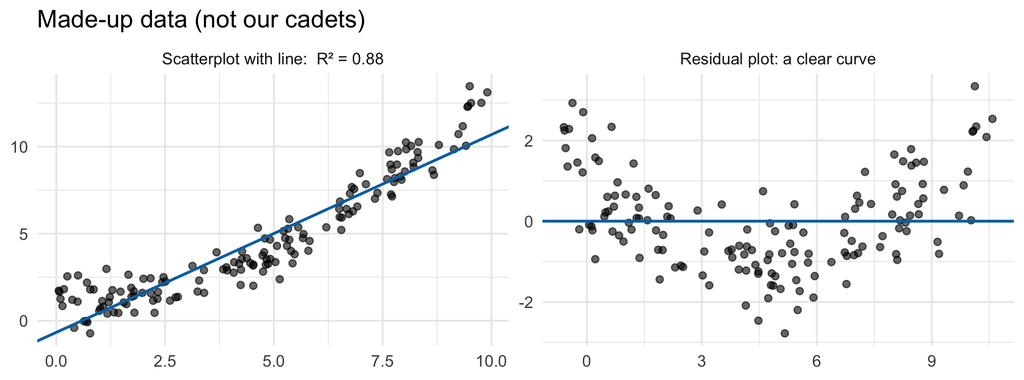

A high $R^2$ doesn’t mean the line is the right **shape**, and it never means **causation**. Always look at the residual plot.

# Outliers

Can one cadet move the line?

## Add one unusual cadet

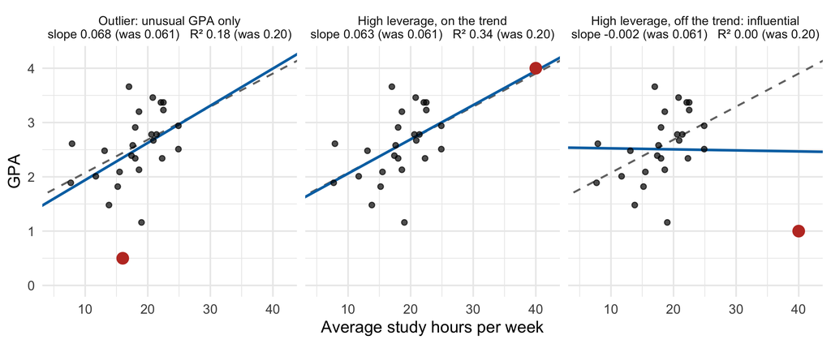

Dashed = original 25 cadets · solid = after adding the **red** cadet

## Three kinds of unusual points

### Outlier

A point that **stands out** from the rest of the cloud

### High leverage

Unusual **$x$** value, far left or right. It **can** pull hard on the line.

### Influential

A point that **actually changes the slope**. Refit without it: the line moves a lot.

**Don’t just delete unusual points.** Fit the model **with and without** them and report both.

# Is This a Good Model?

Putting it all together for our cadets

## Checklist: GPA vs. study hours

| Check | Our cadets |
| --- | --- |
| **Scatterplot:** is the form linear? | Yes: positive, roughly linear |
| **Residual plot:** random scatter around 0? | Yes: no curve or fan (the sharp top edge is the 4.0 GPA cap) |
| **$R^2$:** how much does the line explain? | 0.22: a real trend, but most of GPA is unexplained |
| **Unusual points:** any one cadet running the show? | No: 4,035 cadets, none far out on study hours |
| **Predicting inside the data?** | Only for about 3 to 31 hours |

A **reasonable** line that explains **some**, not most, of the variation in GPA